# Imputing Missing Data

Jeffrey B. Arnold

05/19/2015

This example uses the following packages. The important one is **Amelia** which provides functions for multiple imputation.

```r
library("car")
library("dplyr")
library("tidyr")
library("broom")
library("ggplot2")
library("Amelia")
```

## Data

For this example we will run a regression model of infant mortality (number of deaths per 1,000) on GDP per capita, percentage of married women practicing contraception, and average number of years of education for women. This is the data and model used for missing data in Chapter 20 of Fox, *Applied Regression Analysis*, although our methods of imputation and implementations thereof will be different.

We will load the data and do some minor cleaning of it

```r
UN <- read.table("http://socserv.socsci.mcmaster.ca/jfox/Books/Applied-Regression-3E/datasets/UnitedNations.txt") %>%
  add_rownames(var = "country") %>%
  mutate(illiteracyMale = illiteracyMale / 100,
         illiteracyFemale = illiteracyFemale / 100,
         economicActivityMale = economicActivityMale / 100,
         economicActivityFemale = economicActivityFemale / 100,
         contraception = contraception / 100)
```

| variable | description |
| --- | --- |
| `region` | Africa, America, Asia, Europe, Oceania. |
| `tfr` | Total fertility rate, number of children per woman. |
| `contraception` | Percentage of married women using any method of contraception. |
| `educationMale` | Average number of years of education for men. |
| `educationFemale` | Average number of years of education for women. |
| `lifeMale` | Expectation of life at birth for men. |
| `lifeFemale` | Expectation of life at birth for women. |
| `infantMortality` | infant deaths per 1000 live births. |
| `GDPperCapita` | Gross domestic product per person in U.S. dollars. |
| `economicActivityMale` | Percentage of men who are economically active. |
| `economicActivityFemale` | Percentage of women who are economically active. |
| `illiteracyMale` | Percentage of males 15 years of age and older who are illiterate. |
| `illiteracyFemale` | Percentage of females 15 years of age and older who are illiterate. |

Before starting let’s summarize the data

```r
summary(UN)
```

[output not shown]

We are particularly interested in the amount of missing values in each variable. Although `summary()` lists the missingness in each variable, it can be useful to use The function `frac_missing` calculates the fraction of missing values in `x`.

```r
frac_missing <- function(x) {
  sum(is.na(x)) / length(x)
}
```

The amount of missingness in the variables of interests is highest for `educationFemale` at over 63%, followed by contraception at 30%.

```r
UN_miss_by_var <-
  UN %>%
  gather(variable, value) %>%
  group_by(variable) %>%
  summarise(missing = frac_missing(value)) %>%
  arrange(- missing)
UN_miss_by_var
```

```
## Source: local data frame [14 x 2]
##
##                  variable    missing
## 1           educationMale 0.63285024
## 2         educationFemale 0.63285024
## 3           contraception 0.30434783
## 4          illiteracyMale 0.22705314
## 5        illiteracyFemale 0.22705314
## 6    economicActivityMale 0.20289855
## 7  economicActivityFemale 0.20289855
## 8                lifeMale 0.05314010
## 9              lifeFemale 0.05314010
## 10                    tfr 0.04830918
## 11           GDPperCapita 0.04830918
## 12        infantMortality 0.02898551
## 13                country 0.00000000
## 14                 region 0.00000000
```

The function `missmap` in **Amelia** is a useful way to view the missingness of variables in your data

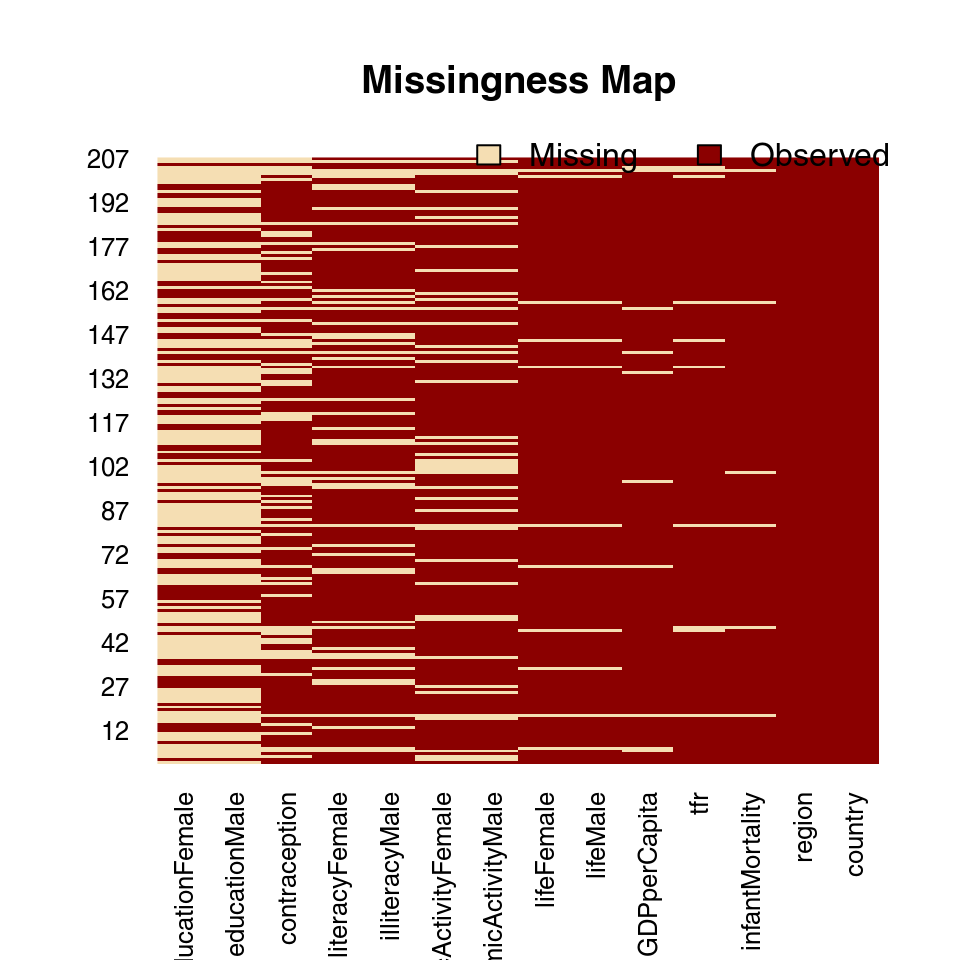

```r
missmap(UN)
```

As an aside, and to show you how the combination of `dplyr`, `ggplot` occupy a nice spot on the flexibility / amount of code frontier,

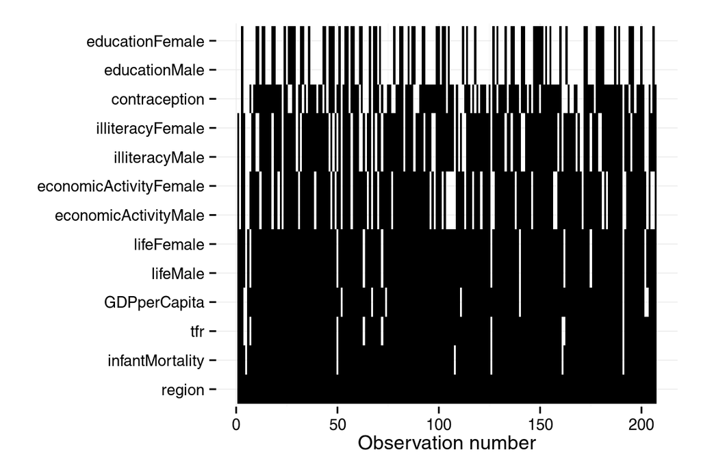

```r
UN_miss_mat <-
  mutate(UN, n = row_number()) %>%
  gather(variable, value, - n) %>%
  mutate(is_na = is.na(value)) %>%
  filter(! variable %in% "country")
ggplot(UN_miss_mat,
       aes(x = reorder(variable, is_na, mean), y = n, fill = is_na)) +
  geom_tile() +
  theme_minimal() +
  coord_flip() +
  # this manually sets the colors of the plot; guide = FALSE removes the legend
  scale_fill_manual(values = c("black", NA), guide = FALSE) +
  xlab("") + ylab("Observation number")
```

Considering that analyses that we will run, with `infantMortality`, `educationFemale`, `contraception`, `GDPperCapita`. What is the level of missingness if we keep only observations will non-missing values in all the variables? Although the original data has observations for 207 countries, 145 (70%) of them have a missing value for at least one of those variables.

```r
UN %>%
  mutate(n = row_number()) %>%
  select(n, infantMortality, educationFemale, contraception, GDPperCapita) %>%
  gather(variable, value, - n) %>%
  group_by(n) %>%
  summarize(any_missing = any(is.na(value))) %>%
  summarise(total = length(n), total_miss = sum(any_missing),
            miss_frac = total_miss / total)
```

```
## Source: local data frame [1 x 3]
##
##   total total_miss miss_frac
## 1   207        145 0.7004831
```

## Models

The model we would like to estimate is to regress Infant Mortality on log GDP, contraception and Female Education.

### Listwise deletion

We will only use rows for which **all** the variables used in the model are non-missing. This is what `lm()` does by default when it encounters missing values.

```r
mod_listwise <-
  lm(infantMortality ~ log(GDPperCapita) + contraception + educationFemale,
     data = UN)
summary(mod_listwise)
```

```
##
## Call:
## lm(formula = infantMortality ~ log(GDPperCapita) + contraception +
##     educationFemale, data = UN)
##
## Residuals:
##     Min      1Q  Median      3Q     Max
## -47.251 -11.145   0.634   7.925  66.125
##
## Coefficients:
##                   Estimate Std. Error t value Pr(>|t|)
## (Intercept)        148.245     11.913  12.444   <2e-16 ***
## log(GDPperCapita)   -7.580      2.365  -3.205   0.0022 **
## contraception      -46.114     17.399  -2.650   0.0103 *
## educationFemale     -2.491      1.386  -1.798   0.0775 .
## ---
## Signif. codes:  0 '***' 0.001 '**' 0.01 '*' 0.05 '.' 0.1 ' ' 1
##
## Residual standard error: 17.9 on 58 degrees of freedom
##   (145 observations deleted due to missingness)
## Multiple R-squared:  0.7466, Adjusted R-squared:  0.7335
## F-statistic: 56.97 on 3 and 58 DF,  p-value: < 2.2e-16
```

### Indicator Variables for Missing Values

For each variable, we will add a dummy variable that is equal 1 if that variable is missing and 0 if not. Then for each variable we will replace its missing values with 0 (or its mean). To assist in that, we will define the function `fill_na` which fills in missing values in `x` with whatever value is given in `fill`.

```r
fill_na <- function(x, fill = 0) {
  x[is.na(x)] <- fill
  x
}
```

Now we generate a new dataset with those dummy variables and with the missing values replaced by their means.

```r
UN_with_dummies <-
  UN %>%
  mutate(GDPperCapita_na = as.integer(is.na(GDPperCapita)),
         GDPperCapita = fill_na(GDPperCapita, mean(GDPperCapita, na.rm = TRUE)),
         contraception_na = as.integer(is.na(contraception)),
         contraception = fill_na(contraception, mean(contraception, na.rm = TRUE)),
         educationFemale_na = as.integer(is.na(educationFemale)),
         educationFemale = fill_na(educationFemale, mean(educationFemale, na.rm = TRUE)))
mod_dummies <- lm(infantMortality ~ log(GDPperCapita) + GDPperCapita_na + contraception +
     contraception_na + educationFemale + educationFemale, data = UN_with_dummies)
mod_dummies
```

```
##
## Call:
## lm(formula = infantMortality ~ log(GDPperCapita) + GDPperCapita_na +
##     contraception + contraception_na + educationFemale + educationFemale,
##     data = UN_with_dummies)
##
## Coefficients:
##       (Intercept)  log(GDPperCapita)    GDPperCapita_na
##          166.4830           -12.5506             3.7953
##     contraception   contraception_na    educationFemale
##          -55.0697             3.5130            -0.4682
```

### Unconditional Mean Imputation

Another ad hoc method is to replace missing values with their means. Since we filled in the missing values in `UN_with_dummies` with the mean values, we will use that, but not include the dummy variables.

These bivariate plots illustrate how unconditional imputation means work, and give an indication of how they will affect results.

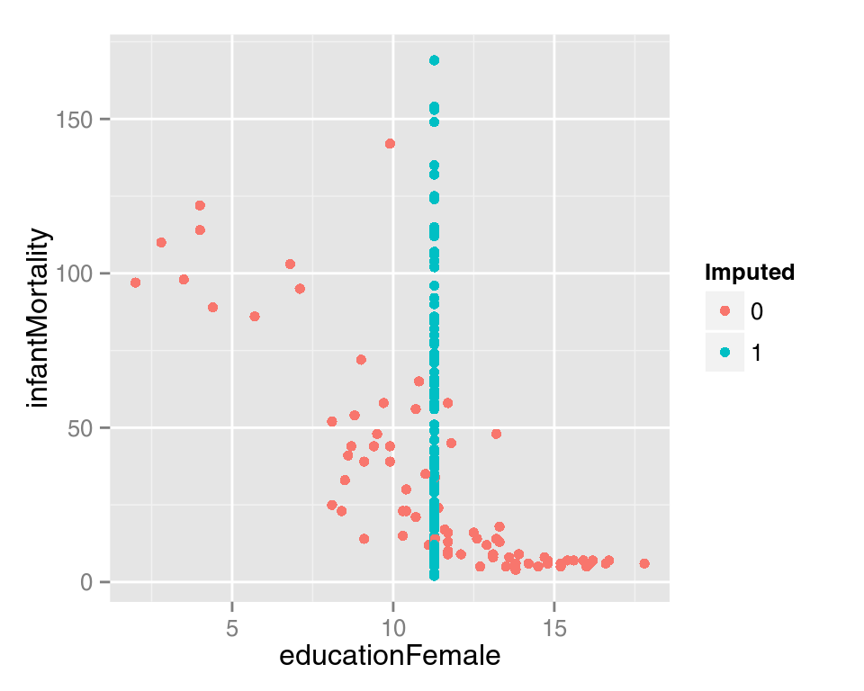

```r
ggplot(UN_with_dummies,
       aes(y = infantMortality, x = educationFemale,
           colour = as.factor(educationFemale_na))) +
  geom_point() +
  scale_colour_discrete("Imputed")
```

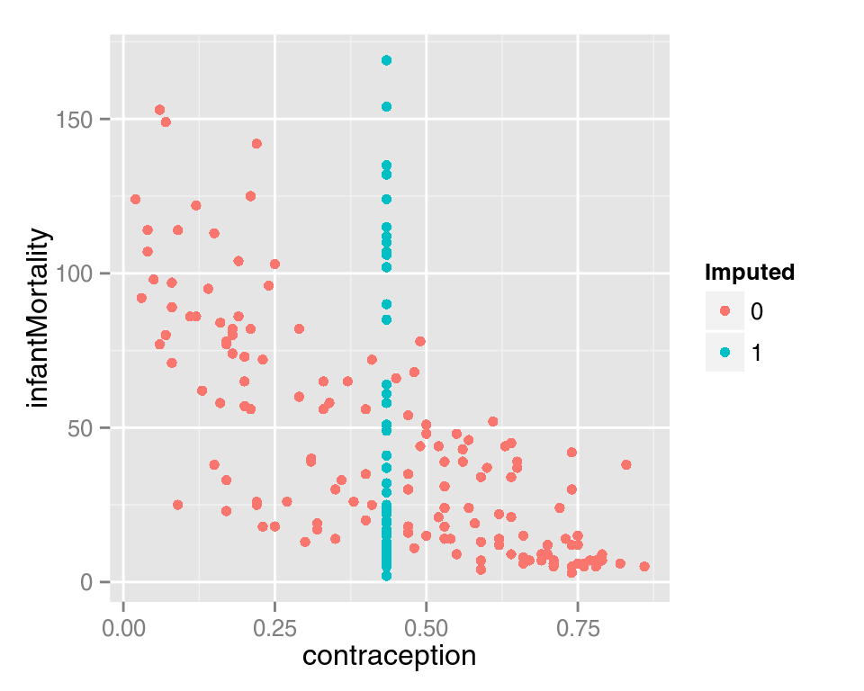

```r
ggplot(UN_with_dummies,
       aes(y = infantMortality, x = contraception,
           colour = as.factor(contraception_na))) +
  geom_point() +
  scale_colour_discrete("Imputed")
```

```r
mod_means <- lm(infantMortality ~ log(GDPperCapita) + contraception +
      educationFemale, data = UN_with_dummies)
mod_means
```

```
##
## Call:
## lm(formula = infantMortality ~ log(GDPperCapita) + contraception +
##     educationFemale, data = UN_with_dummies)
##
## Coefficients:
##       (Intercept)  log(GDPperCapita)      contraception
##          166.5511           -12.2072           -56.1593
##   educationFemale
##           -0.5595
```

### Multiple Imputation

Our **preferred** method is multiple imputation. For multiple imputation we will use the implementation in **Amelia**.[^1] Multiple imputation works by creates $m$ datasets with the missing values filled in with imputations. The analyst then runs the analysis on each of the datasets, and there are (fairly easy) methods to combine the estimates and standard errors from the individual analyses into an overall point estimate and standard error. The function `amelia` creates these imputations.

```r
UN_mi <-
  amelia(UN,
         m = 5,
         logs = c("GDPperCapita"),
         lgstc = c("economicActivityMale", "economicActivityFemale",
                   "illiteracyMale", "illiteracyFemale", "contraception"),
         noms = c("region"),
         idvars = "country")
```

First, the number of imputations is **small**, `m = 5`. There is not much improvement in the performance of multiple imputation from using many imputations. Usually 5–10 is more than sufficient. See Fox, p. 564.

Second, we use the dependent variable as well as variables not used in the regression in the imputation. (Fox, p. 567) This is not an issue. Concerns like endogeneity and multicollinearity are not concerns in this context; we are not interested in estimating unbiased coefficients. We are concerned with predicting the values of these variables.

Let’s see how one of these imputed datasets looks:

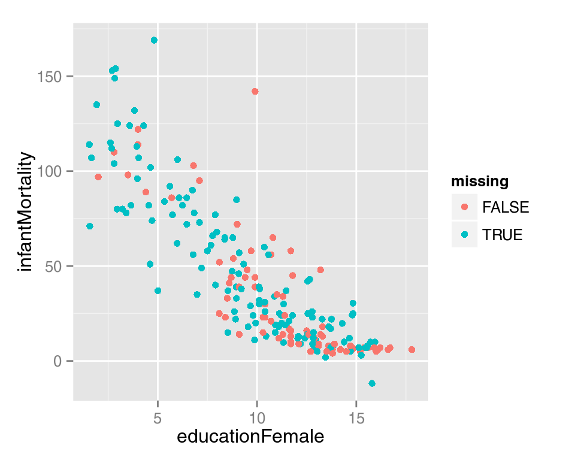

```r
ggplot(UN_mi$imputations[[1]] %>%
         mutate(missing =UN_mi$missMatrix[ , "educationFemale"]),
       aes(x = educationFemale, y = infantMortality, colour = missing)) +
  geom_point()
```

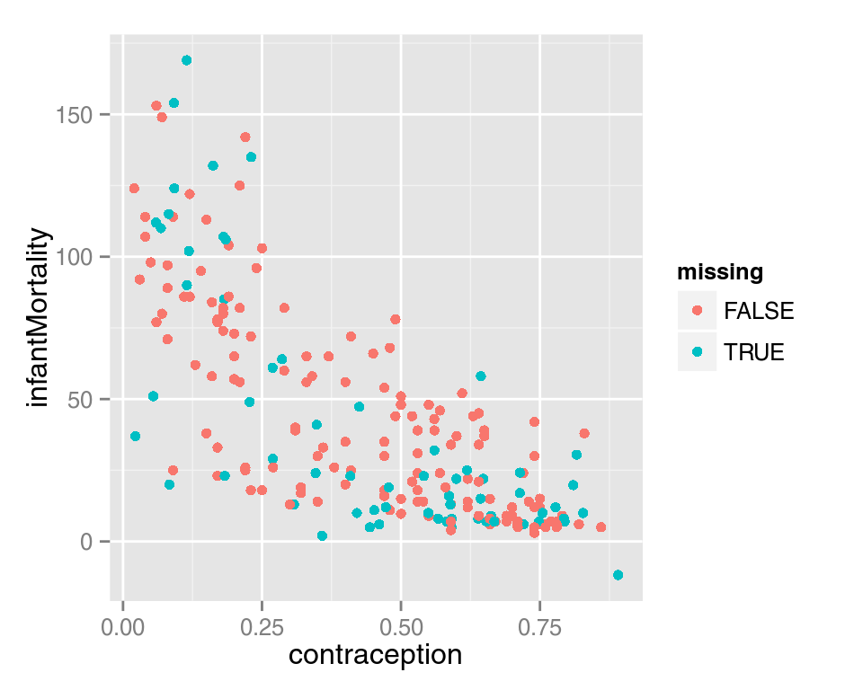

```r
ggplot(UN_mi$imputations[[1]] %>%
         mutate(missing =UN_mi$missMatrix[ , "contraception"]),
       aes(x = contraception, y = infantMortality, colour = missing)) +
  geom_point()
```

The plots we just made suggest **Amelia** is working weel, but let’s look at a couple of diagnostics that **Amelia** suggests: The first is to drop each observation of a variable, impute it, and plot the values against the original values. If the imputed values resemble the original values, then the imputation procedure has worked well.

Amelia suggests several diagnostics for evaluating The first is “overimputation”. This is similar to leave-one-out cross validation. Each observation is removed and treated as a missing value to be imputated. Amelia plots 90% confidence intervals for each observation against the true values. If the imputation is reasonable, then these confidence intervals should have 90% coverage of the true value. The following code runs the overimputation diagnostic for the variables of interest (the ones that will be used in the regression). The overimputation diagnostics do not suggest any issues with the imputation of these variables.

```r
for (var in c("GDPperCapita", "contraception", "illiteracyFemale")) {
  overimpute(UN_mi, var, main = var)
}
```

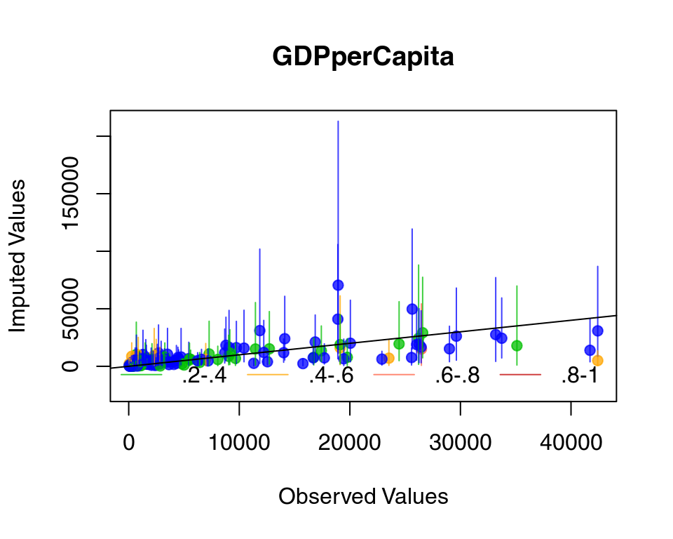

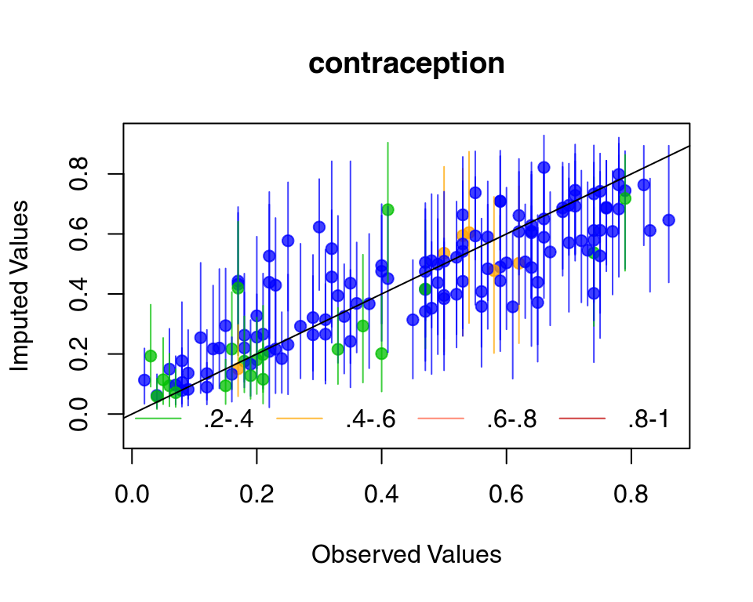

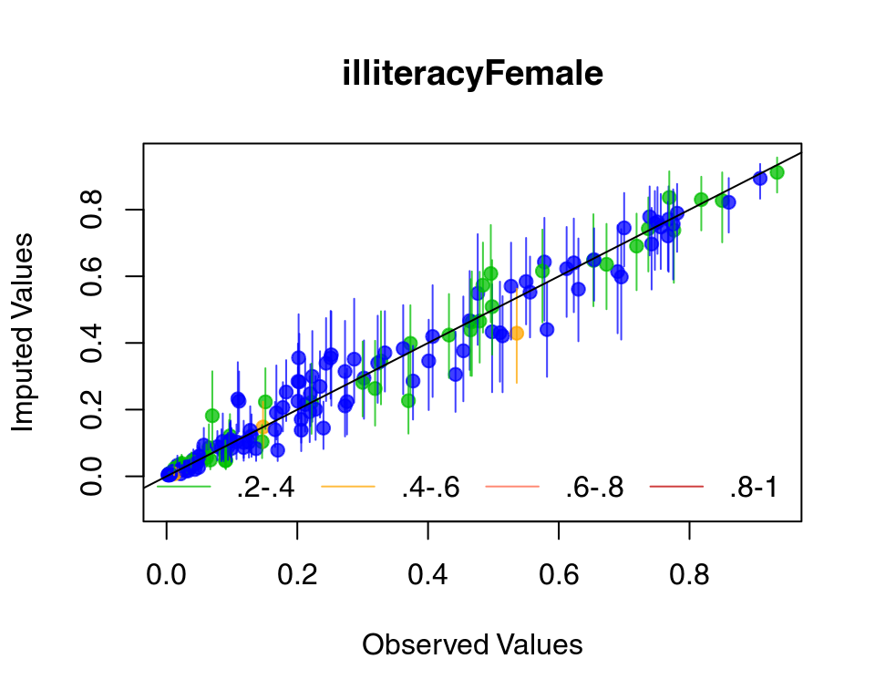

The second method is to plot the marginal density of the imputed values against observed values. If these appear too different, then there *may* be issues with imputation. However, there is no particular criteria for what is **too different**, and there may be reasons why these distributions diverge; see the Amelia vignette for an example of what would be a big difference. But if these distributions are different, then you should revisit the data to see whether imputation makes sense. The following code performs this for each variable of interest. The plots do not suggest any differences to be concerned about.

```r
for (var in c("GDPperCapita", "contraception", "illiteracyFemale")) {
  compare.density(UN_mi, var, main = var)
}
```

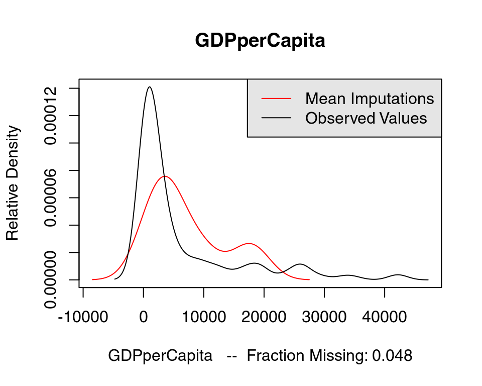

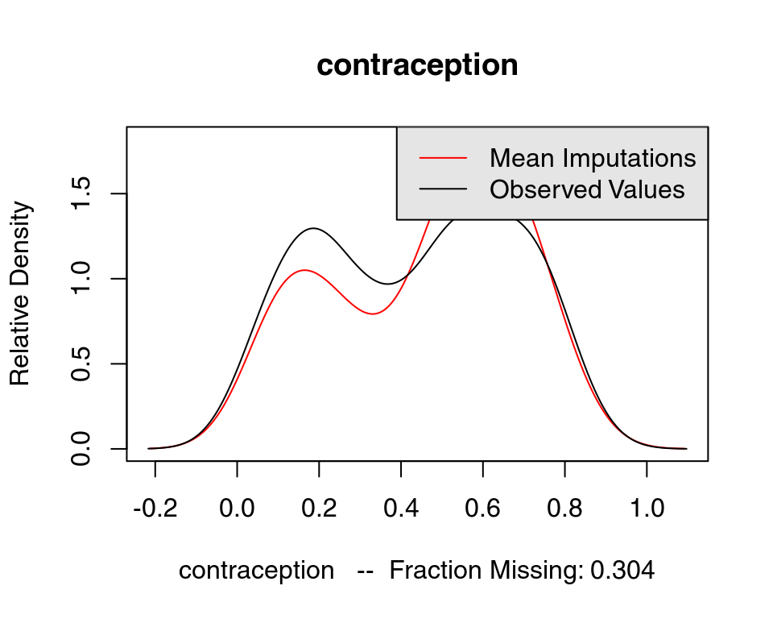

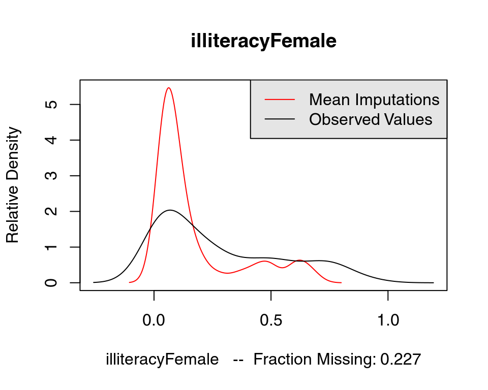

Now that we are satisfied that the imputations are reasonable, we run the analysis on each of the imputated datasets. The following code runs the regression on each imputed dataset saving the coefficients to `b_out`, and the standard errors of the coefficients to `se_out`. These are originally saved to a list, but `rbind` converts it to a matrix with each imputations as rows and coefficients as columns.

Now estimate the model using each imputed dataset. We save the results to `b_out` and `se_out`.

```r
b_out <- list()
se_out <- list()
for (i in seq_along(UN_mi$imputations)) {
  mod <- lm(infantMortality ~ log(GDPperCapita) + contraception + educationFemale, data = UN_mi$imputations[[i]])
  b_out[[i]] <- coef(mod)
  se_out[[i]] <- sqrt(diag(vcov(mod)))
}
b_out <- do.call(rbind, b_out)
se_out <- do.call(rbind, se_out)
```

As described in Fox or Gelman, the coefficients from the imputations can be combined to calculate a single point estimate and standard error. The function `mi.meld` does this, and returns a list with point estimates in the element `q.mi` and standard errors in `se.mi`:

```r
mod_mi_res <- mi.meld(q = b_out, se = se_out)
mod_mi_res
```

```
## $q.mi
##      (Intercept) log(GDPperCapita) contraception educationFemale
## [1,]    137.7723         -2.321946     -36.77929       -5.930536
##
## $se.mi
##      (Intercept) log(GDPperCapita) contraception educationFemale
## [1,]    12.15623          3.226467      21.72784        2.331225
```

### Model Comparison

Now that we’ve estimated this model using various methods to handle missing data, let’s compare the results. First, we combine these into a single dataset. For the results returned by `Amelia`, since there is no `tidy` function defined for Amelia objects we need to manually create a data frame consistent with those returned by `tidy`.

```r
model_comp <-
  bind_rows(tidy(mod_listwise) %>%
              mutate(model = "listwise"),
            tidy(mod_dummies) %>%
              mutate(model = "dummies"),
            tidy(mod_means) %>%
              mutate(model = "means"),
            data_frame(term = colnames(mod_mi_res$q.mi),
                       estimate = as.numeric(mod_mi_res$q.mi),
                       std.error = as.numeric(mod_mi_res$se.mi),
                       model = "mi"))
```

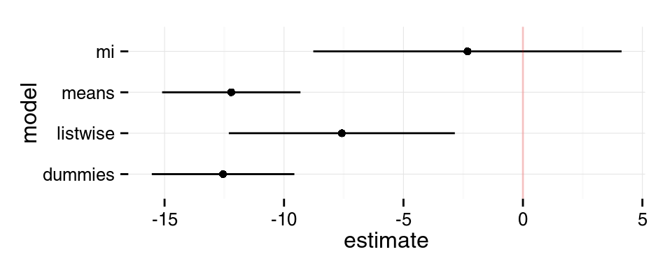

```r
plot_mi_models <- function(data, variable) {
  ggplot(data %>%
         filter(term %in% variable),
         aes(x = model, y = estimate,
             ymin = estimate - 2 * std.error,
             ymax = estimate + 2 * std.error)) +
  geom_pointrange() +
  geom_hline(yintercept = 0, colour = "red", alpha = 0.2) +
  coord_flip() +
  theme_minimal()
}

plot_mi_models(model_comp, "log(GDPperCapita)")
```

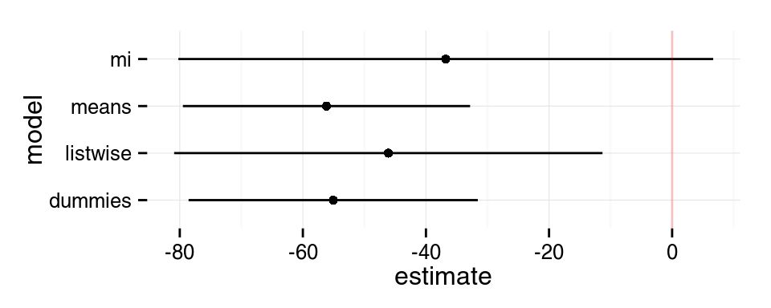

```r
plot_mi_models(model_comp, "contraception")
```

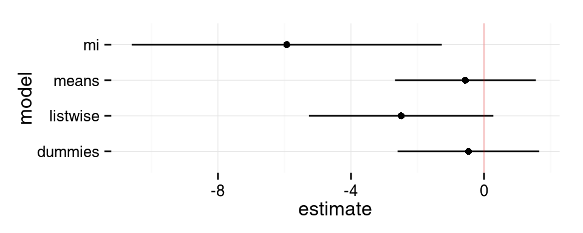

```r
plot_mi_models(model_comp, "educationFemale")
```

[^1]: There are several other R packages that do multiple imputation. For example, [mice](http://www.jstatsoft.org/v45/i03/paper) and [mi](http://www.jstatsoft.org/v45/i02/), which use a different method, called chained equations. We will use **Amelia** because it is stable, works well, and since it is written by Gary King, it is the one that most political scientists are familiar with.